# Cyclistic: Google Data Analytics Capstone Project

Bernard Bamidele Aghedo

#### Background

I’ll be performing the role of a junior data analyst working in the marketing analyst team at Cyclistic, a bike share company in Chicago. The director of marketing believes the company’s future success depends on maximizing the number of annual memberships. Therefore, your team wants to understand how casual riders and annual members use Cyclistic bikes differently. From these insights, your team will design a new marketing strategy to convert casual riders into annual members. But first, Cyclistic executives must approve your recommendations, so they must be backed up with compelling data insights and professional data visualizations.

##### Cyclistic

A bike-share program that features more than 5,800 bicycles and 600 docking stations. Cyclistic sets itself apart by also offering reclining bikes, hand tricycles, and cargo bikes, making bike-share more inclusive to people with disabilities and riders who can’t use a standard two-wheeled bike. The majority of riders opt for traditional bikes; about 8% of riders use the assistive options. Cyclistic users are more likely to ride for leisure, but about 30% use them to commute to work each day.

Loading the available dataset into R

```r
# Loading packages

library("tidyverse")
library("janitor")
library("lubridate")
library("ggplot2")
```

```r
# Set working directory
setwd("~/Desktop/Cyclistic Case Study")
```

```r
# Reading .csv divvy-tripdata files

df1 <- read.csv("202004-divvy-tripdata.csv")
df2 <- read.csv("202005-divvy-tripdata.csv")
df3 <- read.csv("202006-divvy-tripdata.csv")
df4 <- read.csv("202007-divvy-tripdata.csv")
df5 <- read.csv("202008-divvy-tripdata.csv")
df6 <- read.csv("202009-divvy-tripdata.csv")
df7 <- read.csv("202010-divvy-tripdata.csv")
df8 <- read.csv("202011-divvy-tripdata.csv")
df9 <- read.csv("202012-divvy-tripdata.csv")
df10 <- read.csv("202101-divvy-tripdata.csv")
df11 <- read.csv("202103-divvy-tripdata.csv")
df12 <- read.csv("202104-divvy-tripdata.csv")
df13 <- read.csv("202105-divvy-tripdata.csv")
df14 <- read.csv("202106-divvy-tripdata.csv")
df15 <- read.csv("202107-divvy-tripdata.csv")
df16 <- read.csv("202108-divvy-tripdata.csv")
df17 <- read.csv("202109-divvy-tripdata.csv")
df18 <- read.csv("202110-divvy-tripdata.csv")
df19 <- read.csv("202111-divvy-tripdata.csv")
df20 <- read.csv("202112-divvy-tripdata.csv")
df21 <- read.csv("202203-divvy-tripdata.csv")
df22 <- read.csv("202201-divvy-tripdata.csv")
df23 <- read.csv("202202-divvy-tripdata.csv")
df24 <- read.csv("202204-divvy-tripdata.csv")
df25 <- read.csv("202205-divvy-tripdata.csv")
df26 <- read.csv("202206-divvy-tripdata.csv")
```

```r
# binding all csv files

bike_rides <- rbind(df1,df2,df3,df4,df5,df6,df7,
                    df8,df9,df10,df11,df12,df13,
                    df14,df15,df16,df17,df18,df19,
                    df20,df21,df22,df23,df24,df25,df26)
```

```r
unique(bike_rides$member_casual)
```

```
[1] "member" "casual"
```

```r
unique(bike_rides$rideable_type)
```

```
[1] "docked_bike"   "electric_bike" "classic_bike"
```

```r
# Parsing date/time

bike_rides$started_at <- ymd_hms(bike_rides$started_at)

bike_rides$ended_at <- ymd_hms(bike_rides$ended_at)

bike_rides$start_hour <- hour(bike_rides$started_at)

bike_rides$end_hour <- hour(bike_rides$ended_at)

bike_rides$trip_date <- as.Date(bike_rides$started_at)
bike_rides$trip_month <- format(as.Date(bike_rides$trip_date), "%B")
bike_rides$trip_day <- format(as.Date(bike_rides$trip_date), "%d")
bike_rides$trip_year <- format(as.Date(bike_rides$trip_date), "%Y")
bike_rides$trip_weekday <- weekdays(bike_rides$trip_date)
```

```r
# Checking for test stations

unique(bike_rides$start_station_name[grep("test", bike_rides$start_station_name)])
```

```r
# Filtering test stations

bike_rides <- (filter(bike_rides, !(start_station_name == "hubbard_test_lws" |
                                      start_station_name == "")))
```

```r
# To analyze TOP stations

all_trip_stations <- bike_rides[,c(5,9,10)]

all_trip_stations <- all_trip_stations[!duplicated(all_trip_stations$start_station_name),]
```

```r
NROW(unique(all_trip_stations))
```

```
[1] 1321
```

```r
# Calculating Ride Lengths in Minutes

bike_rides$ride_length <- difftime(bike_rides$ended_at, bike_rides$started_at)
bike_rides$ride_length <- bike_rides$ride_length/60
bike_rides$ride_length <- round(bike_rides$ride_length, 2)
```

```r
# Remove observations where ride length is below 0

bike_rides <- filter(bike_rides, ride_length > 0)
```

```r
# Compare members and casual users

bike_rides %>%
  group_by(member_casual) %>%
  summarise(avg_ride_length = mean(ride_length), median_ride_length = median(ride_length),
            max_ride_length = max(ride_length), min_ride_length = min(ride_length))
```

| member_casual | avg_ride_length | median_ride_length | max_ride_length | min_ride_length |
| --- | --- | --- | --- | --- |
| casual | 37.59273 secs | 17.58 secs | 55944.15 secs | 0.02 secs |
| member | 14.40054 secs | 10.15 secs | 58720.03 secs | 0.02 secs |

```r
# Order the days of the week. Will also order the month

bike_rides$trip_weekday <- ordered(bike_rides$trip_weekday,
        levels=c("Sunday", "Monday", "Tuesday", "Wednesday", "Thursday",
                 "Friday", "Saturday"))

bike_rides$trip_month <- ordered(bike_rides$trip_month,
        levels=c("January", "February", "March", "April", "May",
                 "June", "July", "August", "September", "October",
                 "November", "December"))
```

```r
# Avg ride time by each day for members & casual users

casual_member_avg_ride <- aggregate(bike_rides$ride_length ~
                          bike_rides$member_casual + bike_rides$trip_weekday,
                                                 FUN = mean)
```

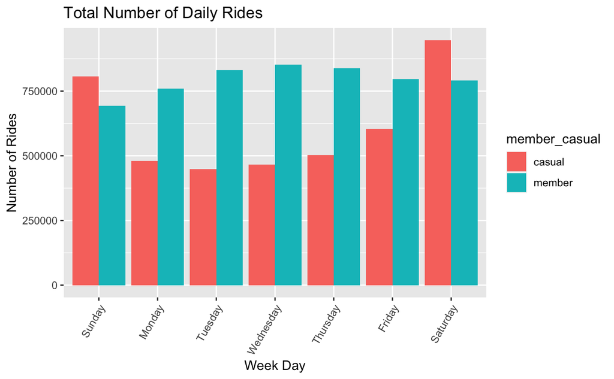

```r
# Relationship between Rider type and No. of rides in each day of the week

bike_rides %>%
  group_by(member_casual, trip_weekday) %>%
  summarise(number_of_rides = n(), average_duration = mean(ride_length)) %>%
  arrange(member_casual, trip_weekday) %>%
 ggplot(aes(x = trip_weekday, y = number_of_rides, fill = member_casual)) +
  geom_bar(position = "dodge", stat = 'identity') +
  labs(title="Total Number of Daily Rides",
            x = "Week Day", y = "Number of Rides") +
  theme(axis.text.x = element_text(angle = 60, hjust = 1))
```

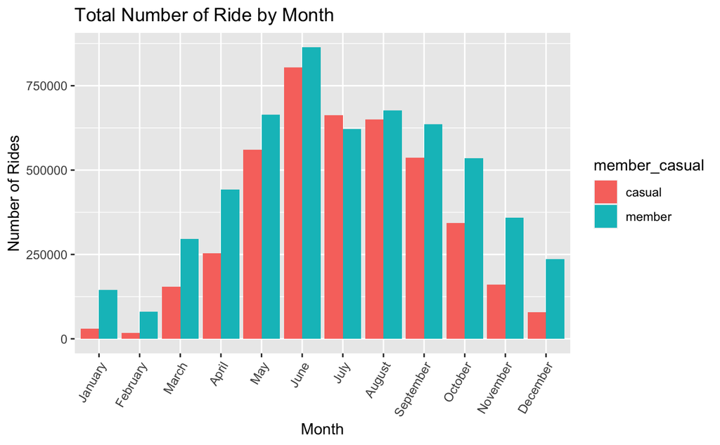

```r
# Relationship between Rider type and No of rides monthly

bike_rides %>%
  group_by(member_casual, trip_month) %>%
  summarise(number_of_rides = n(), average_duration = mean(ride_length)) %>%
  arrange(member_casual, trip_month)    %>%
  ggplot(aes(x = trip_month, y = number_of_rides, fill = member_casual)) +
  geom_col(position = "dodge", stat = 'identity') +
  labs(title="Total Number of Ride by Month", x = "Month", y = "Number of Rides") +
  theme(axis.text.x = element_text(angle = 60, hjust = 1))
```

```r
# Analyze Casual Bike type and rides monthly & daily

casual_bike_riders <-  filter(bike_rides, member_casual == "casual")

unique(casual_bike_riders$rideable_type)
```

```
[1] "docked_bike"   "electric_bike" "classic_bike"
```

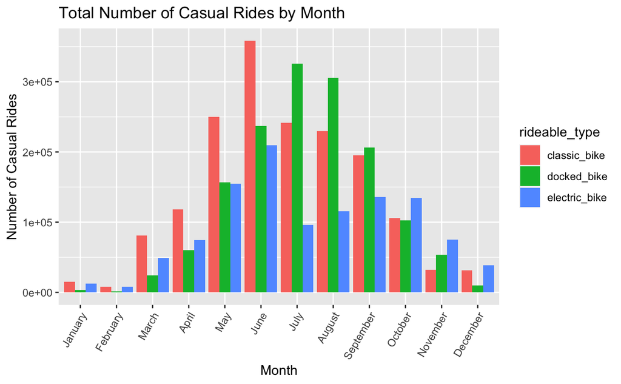

```r
## Casual rides and bike type relationship Monthly

casual_bike_riders %>%
  group_by(rideable_type, trip_month) %>%
  summarise(number_of_rides = n(), average_duration = mean(ride_length)) %>%
  arrange(rideable_type, trip_month)    %>%
  ggplot(aes(x = trip_month, y = number_of_rides, fill = rideable_type)) +
  geom_col(position = "dodge", stat = 'identity') +
  labs(title="Total Number of Casual Rides by Month", x = "Month", y = "Number of Casual Rides") +
  theme(axis.text.x = element_text(angle = 60, hjust = 1))
```

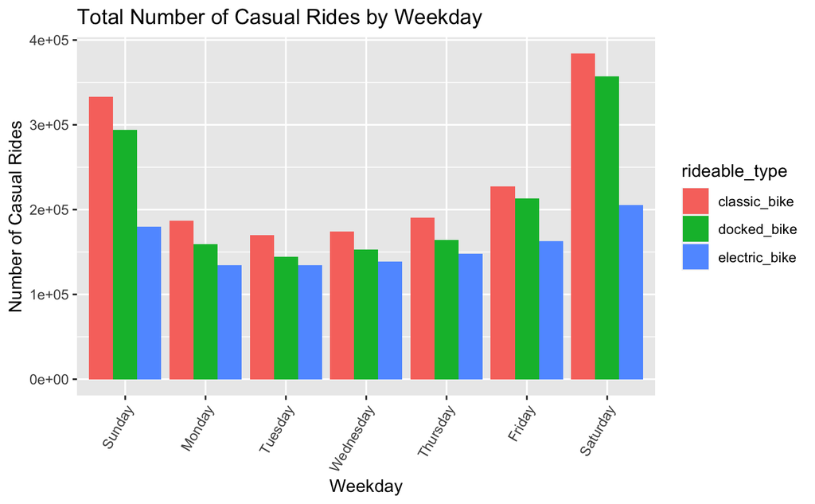

```r
## Casual rides and bike type relationship Daily

casual_bike_riders %>%
  group_by(rideable_type, trip_weekday) %>%
  summarise(number_of_rides = n(), average_duration = mean(ride_length)) %>%
  arrange(rideable_type, trip_weekday)  %>%
  ggplot(aes(x = trip_weekday, y = number_of_rides, fill = rideable_type)) +
  geom_col(position = "dodge", stat = 'identity') +
  labs(title="Total Number of Casual Rides by Weekday", x = "Weekday", y = "Number of Casual Rides") +
  theme(axis.text.x = element_text(angle = 60, hjust = 1))
```

```r
# Analyze Member Bike type and rides monthly & daily

member_bike_riders <- filter(bike_rides, member_casual == "member")
```

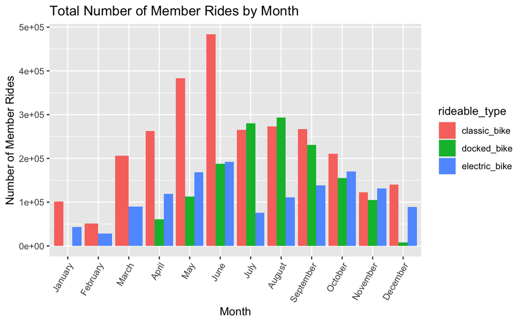

```r
## Member rides and bike type relationship Monthly

member_bike_riders %>%
  group_by(rideable_type, trip_month) %>%
  summarise(number_of_rides = n(), average_duration = mean(ride_length)) %>%
  arrange(rideable_type, trip_month)    %>%
  ggplot(aes(x = trip_month, y = number_of_rides, fill = rideable_type)) +
  geom_col(position = "dodge", stat = 'identity') +
  labs(title="Total Number of Member Rides by Month", x = "Month", y = "Number of Member Rides") +
  theme(axis.text.x = element_text(angle = 60, hjust = 1))
```

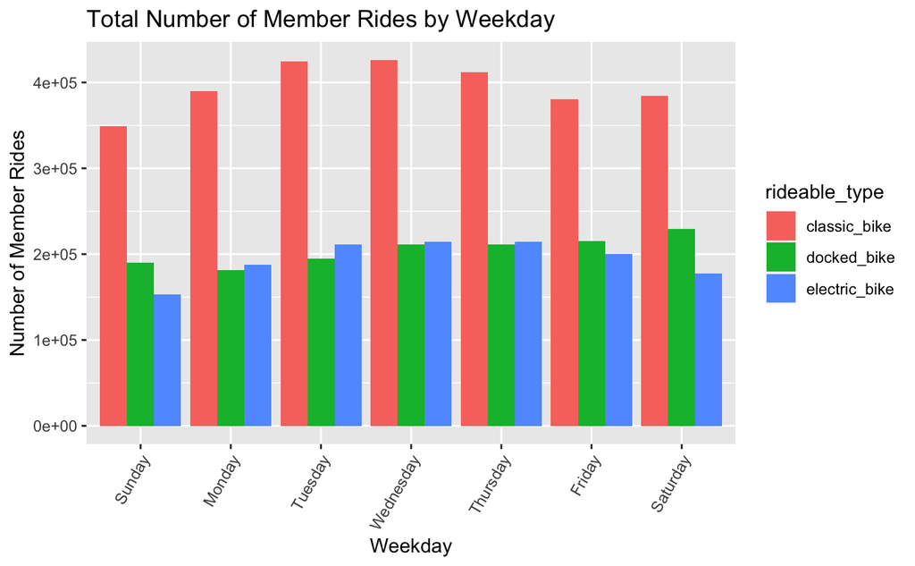

```r
## Member rides and bike types relationship Daily

member_bike_riders %>%
  group_by(rideable_type, trip_weekday) %>%
  summarise(number_of_rides = n(), average_duration = mean(ride_length)) %>%
  arrange(rideable_type, trip_weekday)  %>%
  ggplot(aes(x = trip_weekday, y = number_of_rides, fill = rideable_type)) +
  geom_col(position = "dodge", stat = 'identity') +
  labs(title="Total Number of Member Rides by Weekday", x = "Weekday", y = "Number of Member Rides") +
  theme(axis.text.x = element_text(angle = 60, hjust = 1))
```

```r
# Popular Routes taken by casual riders

casual_bike_riders <- casual_bike_riders %>%
  mutate(route = paste(start_station_name, "To", sep=" "))

casual_bike_riders <- casual_bike_riders %>%
  mutate(route = paste(route, end_station_name, sep =" "))

casual_pop_routes <-  casual_bike_riders %>%
  group_by(route) %>%
  summarise(number_of_rides  = n(), average_duration_minutes = mean(ride_length)) %>%
  arrange(route, number_of_rides, average_duration_minutes)
```

```r
## Calculating Top 10 stations for casual riders

top10_casual_pop_routes <- head(arrange(casual_pop_routes, desc(number_of_rides)), 10)

top10_casual_pop_routes <- top10_casual_pop_routes %>%
  separate(route, c("start_station_name", "end_station_name"), sep = " To ")

unique(top10_casual_pop_routes)
```

[output not shown]

```r
# Top 10 popular Routes taken by Member riders

member_bike_riders <- member_bike_riders %>%
  mutate(route = paste(start_station_name, "To", sep=" "))

member_bike_riders <- member_bike_riders %>%
  mutate(route = paste(route, end_station_name, sep =" "))

member_pop_routes <-  member_bike_riders %>%
  group_by(route) %>%
  summarise(number_of_rides  = n(), average_duration_minutes = mean(ride_length)) %>%
  arrange(route, number_of_rides, average_duration_minutes)
```

```r
# Calculating Top 10 stations for member riders

top10_member_pop_routes <- head(arrange(member_pop_routes, desc(number_of_rides)), 10)

top10_member_pop_routes <- top10_member_pop_routes %>%
  separate(route, c("start_station_name", "end_station_name"), sep = " To ")

unique(top10_member_pop_routes)
```

[output not shown]

```r
# Export "top10_stations_casual" and "top10_stations_member" into Tableau for visualization

write.csv(top10_stations_casual, "top10_stations_casual.csv")
write.csv(top10_stations_member, "top10_stations_member.csv")
```

#### link to Dashboard Tableau Viz: Top 10 casual and member stations

###### https://public.tableau.com/views/DashboardCyclisticBikeShare-Top10Member_CasualStation/CyclisticBikeShare-Top10Member_CasualStations

#### Trends and Correlations

Member riders have more rides during the week which is between Mondays to Fridays While Casual have more rides during weekends which is Saturdays and Sundays